# Quick Graphs in Python

## Chansoo Song and Gautam Sisodia

1. what are graphs?
2. history
3. use cases
4. graph algorithms
5. graphs in python: networkx
6. example: academic connections between universities
7. conclusion

# What are graphs?

A graph is a mathematical structure consisting of a set of objects called **nodes** and a set of connections between them called **edges**

| example graph |
| --- |
| [User:AzaToth [Public domain], via Wikimedia Commons](https://commons.wikimedia.org/wiki/File:6n-graf.svg) |

## Directed edges

| friends |
| --- |
| Petrona Viera [Public domain], via [Wikimedia Commons](https://commons.wikimedia.org/wiki/File:El_cuentito.jpg) |

## Node and edge properties

- nodes and edges can have properties
- most common: a number called a **weight**
- example: nodes = subway stations, edges = tracks between stations
  - edge weight = length of tracks

| NYC subway |
| --- |
| CountZ at English Wikipedia [CC BY-SA 3.0], via [Wikimedia Commons](https://commons.wikimedia.org/wiki/File:NYC_subway-4D.svg) |

# History

## Seven bridges of Koningsburg

- city in Prussia (now Kaliningrad, Russia)
- is it possible to walk through the city, crossing each bridge once and only once?

| Koningsburg |
| --- |
| [Merian-Erben [Public domain], via Wikimedia Commons](https://commons.wikimedia.org/wiki/File:Image-Koenigsberg,_Map_by_Merian-Erben_1652.jpg) |

## Euler's solution

- Leonhard Euler realized it was useful to think of the landmasses of the city as objects (nodes) and bridges as connections between them (edges)
- was able to prove in 1736 that no such path was possible
- laid the foundations for the study of graphs in math

| Euler | Koningsburg graph |
| --- | --- |
| [Jakob Emanuel Handmann [Public domain], via Wikimedia Commons](https://commons.wikimedia.org/wiki/File:EulerLeonhard.jpg) | [Mark Foskey [Public domain], via Wikimedia Commons](https://commons.wikimedia.org/wiki/File:K%C3%B6nigsberg_graph.png) |

## A nice graph theory result

- Four color theorem: four colors are enough to color every region of a map such that no two regions that touch have the same color

| Four coloring of US states |
| --- |
| User:Derfel73; User:Dbenbenn [CC BY-SA 3.0], via [Wikimedia Commons](https://commons.wikimedia.org/wiki/File:Map_of_USA_four_colours.svg) |

# Use cases

| Airport graph |
| --- |
| [Martin Grandjean [CC-BY-SA]](http://www.martingrandjean.ch/connected-world-air-traffic-network/) |

## Entity resolution

- example: identifying people with names, phone numbers and addresses
- identifiers are fuzzy: can have variations, can change
- a graph can help keep track of correpondences between identifier values

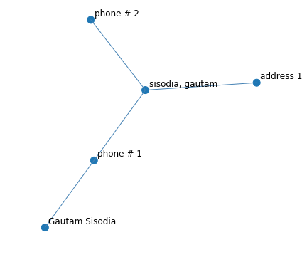

```python
fig, ax = plt.subplots(figsize = (6, 6))
draw_graph_layout_cent(graph = entity_res_ex, layout = nx.kamada_kawai_layout(entity_res_ex), ax = ax, edge_lw = 1, node_size = 100)
```

## Multilayer Networks

- example:
  - twitter: tweets, retweets, mentions
  - transport: subway, bus, trains

[figure not shown]

(source: Aleta and Moreno)

# Graph algorithms

## Path finding

- finding optimal paths in a graph
- example: Dijkstra's algorithm, 1956
- example use: Bacon number (six degrees of separation from Kevin Bacon)

[figure not shown]

http://oracleofbacon.org

## Centrality

- Identify most "important" nodes
- Examples:
  - Degree, Closeness, Betweenness, Eigenvector
- Eigenvector Centrality

[figure not shown]

## Community detection

- finding groups of nodes more connected to nodes within their group than without
- example: label propagation
  - iterative algorithm where each node updates its label to the most common label of its neighbors

| graph with community structure |
| --- |
| j_ham3 [CC BY-SA 3.0], via [Wikimedia Commons](https://commons.wikimedia.org/wiki/File:Network_Community_Structure.svg) |

# Graphs in python: networkx

networkx is a python package for creating and working with graphs

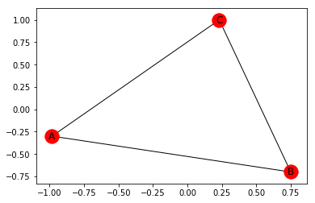

```python
import networkx as nx
graph = nx.Graph()
graph.add_edges_from([("A", "B"), ("B", "C"), ("A", "C")])
nx.draw_networkx(graph)
```

## Koningsburg graph

```python
koningsburg = nx.MultiGraph()
koningsburg.add_edges_from([("A", "B"), ("A", "B"), ("B", "C"), ("B", "C"), ("A", "D"), ("B", "D"), ("C", "D")])
nx.is_eulerian(koningsburg)
```

```
False
```

# Example: academic connections between universities

- the Mathematics Genealogy Project (https://genealogy.math.ndsu.nodak.edu/) collects information on math, computer science, statistics academics, including when and where they got their PhD and when and where their students got their PhDs
- can we use this information to spot trends in the movements of academics between universities

[output not shown]

## School graph

- nodes are schools
- edge from A to B if a person got their PhD from school A and advised a student at school B (directed)
- weight is the number of such people

#### Summary Statistics:

```python
print(nx.info(school_digraph))
```

```
Name:
Type: DiGraph
Number of nodes: 3358
Number of edges: 31547
Average in degree:   9.3946
Average out degree:   9.3946
```

[figure not shown]

#### Show Subset

[figure not shown]

# Hierarchy of Schools over Time

#### Degree Centrality

[figure not shown]

#### Eigenvector Centrality

[figure not shown]

#### Berkeley Degree Centrality

[figure not shown]

#### Berkeley Eigenvector Centrality

[figure not shown]

#### Lomonosov Degree Centrality

[figure not shown]

#### Lomonosov Eigen Centrality

[figure not shown]

#### Top Schools by Eigen Centrality

[figure not shown]

## Grouped by Country

[figure not shown]

## Community Detection

- label propogation applied to the top 25 schools by degree in the 2010s
- community almost exactly corresponds to country

[figure not shown]

# Conclusion

## Beyond networkx

### Visualization

- https://cytoscape.org/, https://www.graphviz.org/

### Larger graphs

- https://neo4j.com/